# Impact of fishing pressure on California Spiny Lobster abundance and community size structure along the Santa Barbara Coast

Shuhan Song, Siya Qiu

November 10, 2019

### Introduction

The California Spiny Lobster (*Panulirus interruptus*) is one of the most important keystone species in the giant kelp forests ecosystem off southern California. The species has been managed by the state of California for more than 100 years due to its significant values in commercial and recreational fisheries (California Department of Fish and Wildlife, 2016). In 2000, the Santa Barbara Coastal Long-Term Ecological Research (SBC LTER) was established to study coastal kelp forest (SBC, 2019). The report by California Department of Fish and Wildlife (CDFW) in 2011 suggested the increasing recreational fishery might be pushing the stock of spiny lobsters to the edge of decline (Neilson, 2011). In 2012, the SBC LTER began to collect data of California Spiny Lobsters from Marine Protected Area (MPA) and non-MPA (Reed, 2019) to understand how fishing pressure affected the bio-dynamics inside kelp forests. In this report, we analysed the SEC LTER data to see how fishing pressures affect the California Spiny Lobster polulation. We visualized the lobster population abundance and size structures of the five sites from 2012 to 2018, and specifically, compared the 2012 and 2018 size structures in each site. We then analyzed whether the MPA lobster size structures were significantly differ from those of non-MPA in 2012 and 2018 respectively. Finally, we analyzed whether the 2012 lobster size structures were significantly differ from those in 2018 for MPA and non-MAP lobsters respectively.

### Data and Methods

The California Spiny Lobster’s data was collected by SBC LTER from five sites: with two (Naples and Isla Vista) from MPA (marine protected area), and three (Arroyo Quemado, Mohawk, and Carpinteria) from non-MPA, for a time period from 2012 to 2018 (Reed, 2019). Data was collected every two to four weeks during the lobster fishing season (October to March) (Reed, 2019), including parameters “year” (which year the data was collected), “size” (size of lobster in mm), “site” (which site the data was collected)…etc. In this report, we calculated the mean, medium, standard veriation, sample size, and confidence interval of lobster size for MPA and non-MPA in year 2012 and 2018 respectively. We analyzed whether there is significance difference between: 2012 MPA and 2012 non-MPA, 2018 MPA and 2018 non-MPA, 2012 MPA and 2018 MPA, 2012 non-MPA and 2018 non-MPA, by using two sample t-test ($\alpha$ = 0.05 throughout), and calculating the effecting size. All analyses and figures were prepared using R software version 3.6.1.

### Results

#### A. Annual abundance of lobsters at each site

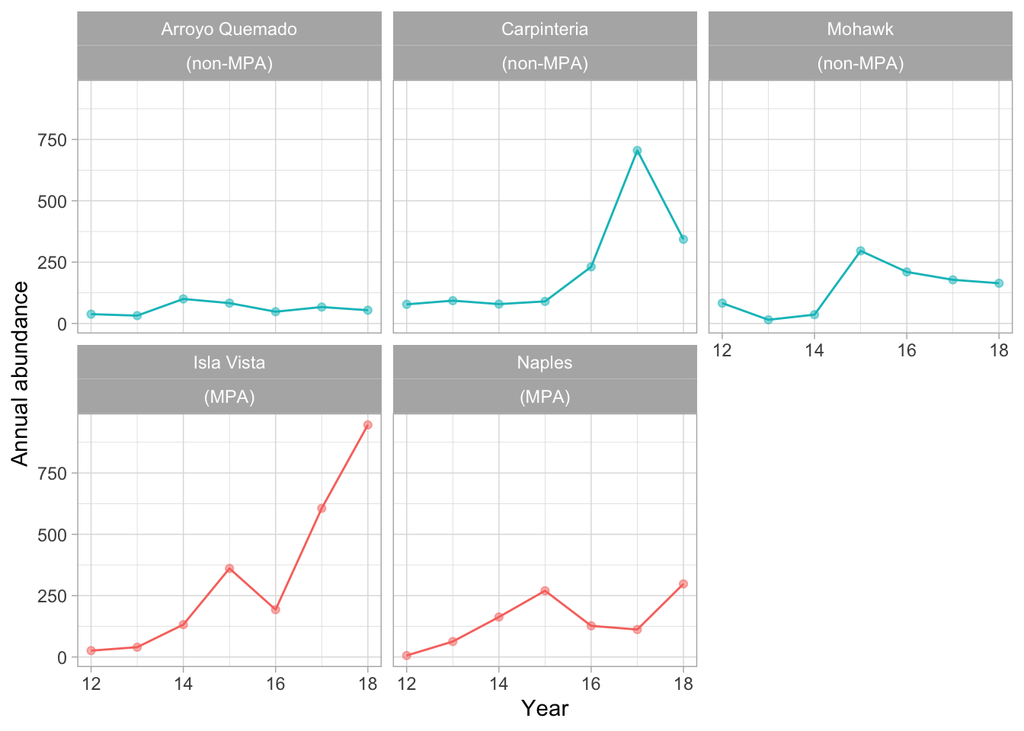

**Figure 1.** The changes in annual abundance of spiny lobsters at each site (2012-2018). Sites were from both MPAs (red) and non-MPAs (blue). Data: SBC LTER

#### B. The shift of lobster size distribution at each site

Lobster size distribution presented different levels of shifts at each site comparing 2018 to 2012 (Figure 2). For the two MPA sites, Isla Vista and Naples, the size structure of lobster population shifted significantly to the right comparing 2018 to 2012 with protections against fishing pressure. However, for those in non-MPAs, lobsters did not grow larger if not dropped to even smaller sizes than 2012.

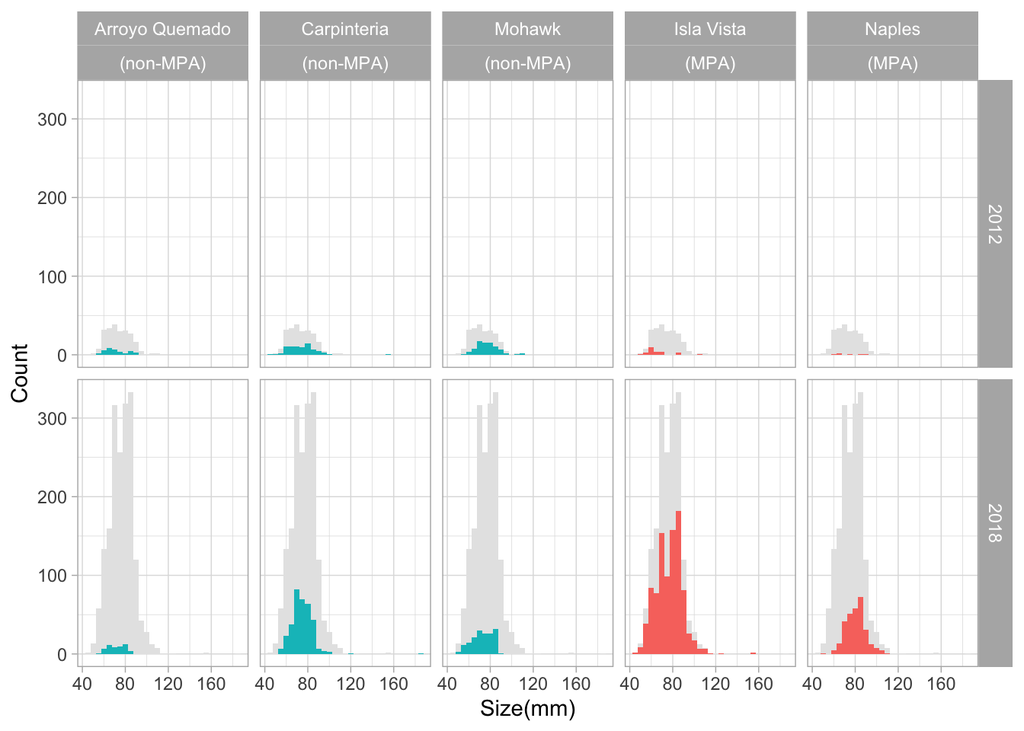

**Figure 2.** The shift of loster size distribution in 2012 and 2018 by site. In 2012, sites in non-MPA (blue) had more larger sizes lobsters than sites in MPA (red). In 2018, lobsters in MPAs had larger sizes than those from non-MPAs. Data: SBC LTER

#### C. Lobster sizes at MPA and non-MPA sites in 2012 and 2018

The summary statistics of mean lobster sizes were calculated for four scenarios (Table 1) and four two-sample t-tests were performed with results shown below.

**Table 1.** Summary of spiny lobster size for MPA and non-MPA sites in 2012 and 2018. For non-MPA sites, lobster size did not change much from 2012 (mean = 74.92 , sd = 12.41, n = 199) to 2018 (mean = 73.62 , sd = 10.09, n = 561). For MPA sites, lobster size increased between 2012 (mean = 67.38 , sd = 12.15, n = 32) and 2018 (mean = 77.57 , sd = 11.7, n = 1244). Data: SBC LTER

| Year | MPA | Mean | Median | Standard Deviation | Sample Size | Confidence Interval lower bound | Confidence Interval upper bound |
| --- | --- | --- | --- | --- | --- | --- | --- |
| 2012 | MPA | 67.38 | 64.5 | 12.15 | 32 | 55.23 | 79.53 |
| 2012 | non-MPA | 74.92 | 75.0 | 12.41 | 199 | 62.51 | 87.33 |
| 2018 | MPA | 77.57 | 78.0 | 11.70 | 1244 | 65.87 | 89.27 |
| 2018 | non-MPA | 73.62 | 73.0 | 10.09 | 561 | 63.53 | 83.71 |

**MPA vs. non-MPA sites in 2012**

For 2012 observations, mean lobster sizes (mm) measured in samples collected from MPA sites (67.38 $\pm$ 12.15, n = 32) differed significantly from size of lobsters in non-MPA sites (74.92 $\pm$ 12.41, n = 199) by a two-sample t-test (t(42) = -3.25, *p* = 0.0023, 95% CI = (-12.23, -2.86)). The sample sizes for the two groups were not balanced where that for MPA group was small. With the *p*-value, there is a 0.23% chance that we could have found two samples at least as different as ours if they were drawn from two populations with the same means. In addition, if we took many samples and found the confidence intervals, we’d expect 95% of those confidence intervals to included the population mean differece. So it’s highly likely that a calculated confidence interval contains the population mean difference, where 0 was not included. The difference in mean lobster sizes between MPA and non-MPA sites was 7.54mm, with a medium effect size (Cohen’s d = -0.61).

We could reject the null hypothesis based on the statistic output. There were a significant difference in lobster sizes between MPA and non-MPA sites in 2012. But if we could have a larger sample size for MPA 2012, we might be able to further improve the analysis outcome.

**MPA vs. non-MPA sites in 2018**

For 2018 observations, mean lobster sizes (mm) measured in samples collected from MPA sites (77.57 $\pm$ 11.7, n = 1244) differed significantly from lobster sizes in non-MPA sites (73.62 $\pm$ 10.09, n = 561) by a two-sample t-test (t(1239) = 7.31, *p* <0.0001, 95% CI = (2.89, 5.01)). Based simply on *p*-value, there was an extremely rare chance that we could have found two samples at least as different as ours if they were drawn from two populations with the same means. In addition, if we took many samples and found the confidence intervals, we’d expect 95% of those confidence intervals to included the population mean differece. So it’s highly likely that a calculated confidence interval contains the population mean difference, where 0 was not included. However, the difference in mean lobster sizes between MPA and non-MPA sites was 3.95mm, with a small effect size (Cohen’s d = 0.35).

We could reject the null hypothesis based on the statistic output with limited effect. There were a significant but hard-to-detect difference in lobster sizes between MPA and non-MPA sites in 2018. However, the significant t-test result might also be a result of the large sample sizes of the two groups, especially the MPA sites.

**2012 vs. 2018 for MPA sites**

**2012 vs. 2018 for non-MPA sites**

### Summary

MPA does a great job in protecting lobsters by significantly increasing both lobster size and aboundance comparing to non-MPA sites.

### References

California Department of Fish and Wildlife. 2016. California spiny lobster fishery management plan. https://www.wildlife.ca.gov/Conservation/Marine/Lobster-FMP. Accessed 11/17/2019.

Neilson, D. J. 2011. Assessment of the California spiny lobster (Panulirus interruptus). California Department of Fish and Game, Final Report, San Diego. https://www.wildlife.ca.gov/Conservation/Marine/Lobster-FMP/Assessment. Accessed 11/17/2019.

Reed D. 2019. SBC LTER: Reef: Abundance, size and fishing effort for California Spiny Lobster (*Panulirus interruptus*), ongoing since 2012. Environmental Data Initiative. https://doi.org/10.6073/pasta/a593a675d644fdefb736750b291579a0.

SBC. 2019. “Santa Barbara Coastal.” Santa Barbara Coastal LTER, http://bclter.msi.ucsb.edu/.